# Лабораторная Работа №6. Мандатное разграничение прав в Linux

Основы информационной безопасности

Барсегян В.Л.

Российский университет дружбы народов им. Патриса Лумумбы, Москва, Россия

## Докладчик

# Вводная часть

## Цели и задачи

Развить навыки администрирования ОС Linux. Получить первое практическое знакомство с технологией SELinux. Проверить работу SELinx на практике совместно с веб-сервером Apache.

# Выполнение лабораторной работы

## Убеждаюсь, что SELinux работает в режиме enforcing политики targeted с помощью команд *getenforce* и *sestatus*. Запускаю веб-сервер командой *service httpd start* и проверяю его статус командой *service httpd status*

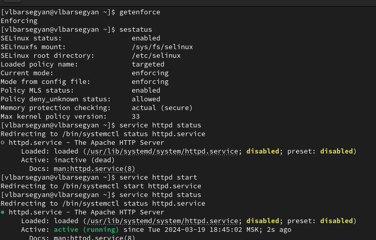

Запуск и проверка веб-сервера

## Определяю контекст безопасности веб-сервера с помощью команды *ps auxZ | grep httpd*

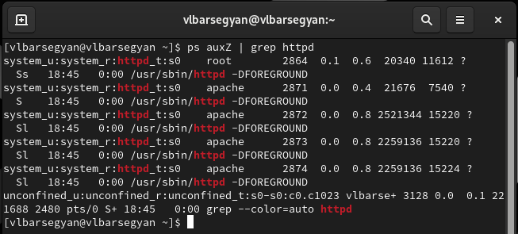

Контекст безопасности веб-сервера

## Просматриваю текущее состояние переключателей SELinux для Apache с помощью команды *sestatus -b | grep httpd*

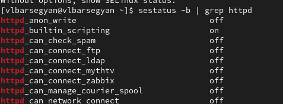

Состояние переключателей SELinux

## Смотрю статистику по политике с помощью команды *seinfo*

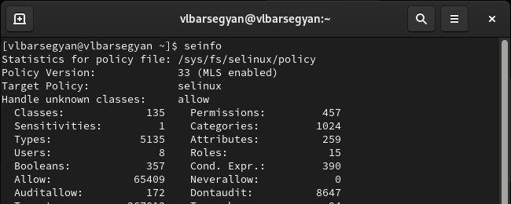

Статистика по политике

## Определяю тип файлов и поддиректорий, находящихся в директории /var/www, с помощью команды *ls -lZ /var/www*. Аналогично для директории /var/www/html

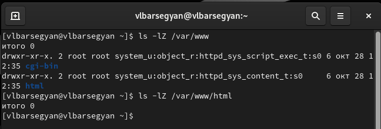

Определение типа файлов и папок

## Создаю файл /var/www/html/test.html и записываю следующий html-код

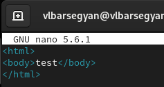

test.html

## Проверяю контекст созданного файла командой *ps auxZ | grep test.html*

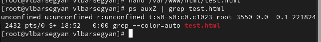

Контекст файла

## Проверяю в браузере, что файл успешно отображается

[figure not shown]

Проверка в браузере

## Изучаю справку man по командам httpd и selinux, также проверяю контекст файла командой *ls -Z /var/www/html/test.html*

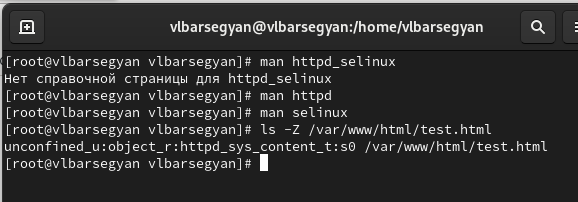

Изучение man, проверка контекста

## Изменяю контекст файла test.html командой *chcon -t samba_share_t /var/www/html/test.html*. После, проверяю его и открываю веб-страницу - нет доступа

[figure not shown]

Изменение контекста

## Просматриваю системный лог-файл командой *tail /var/log/messages*

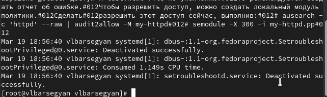

Системный лог-файл

## В файле /etc/httpd/conf/httpd.conf меняю порт на 81

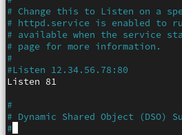

Смена порта

## Перезагружаю веб-сервер - получен сбой

[figure not shown]

Сбой веб-сервера

## Анализирую лог-файлы командами *tail -nl /var/log/messages* и *cat /var/log/http/error_log*

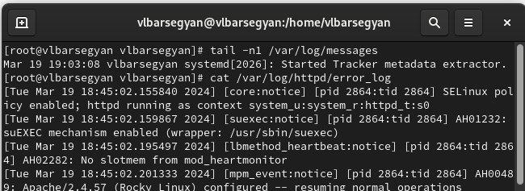

Проверка лог-файлов

## Также проверяю лог-файл */var/log/http/access_log*

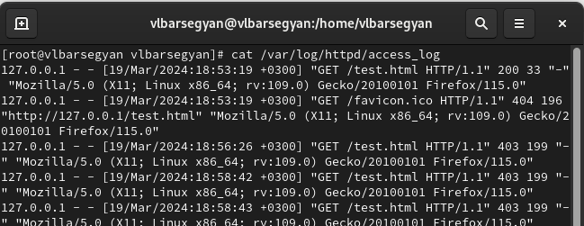

Проверка лог-файлов

## Также проверяю лог-файл */var/log/audit/audit.log*.

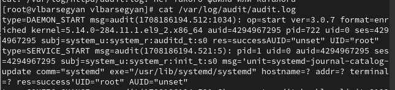

Проверка лог-файлов

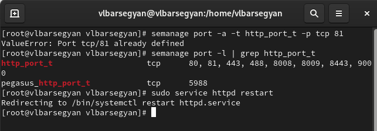

## Возвращаю контекст httpd_sys_cоntent__t к файлу /var/www/html/ test.html, введя *chcon -t httpd_sys_content_t /var/www/html/test.html*. Перезапускаю веб-сервер командой *sudo service httpd restart*

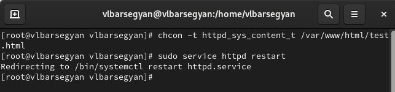

Возвращение контекста и перезапуск веб-сервера

## Возвращаю порт 80 в конфигурационном файле

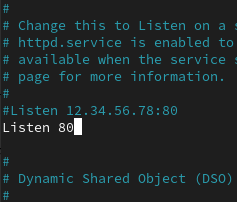

Смена порта на 80

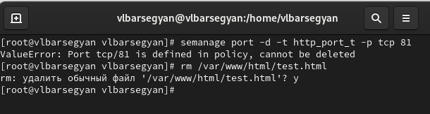

# Вывод

Я развил навыки администрирования ОС Linux, познакомился с технологией SELinux, поработал с веб-сервером Apache